# Antimicrobial Resistance in Spain (2000–2018)

Patrícia Cózar Torrell

2026-01-14

## 0.1 Introduction

Antimicrobial resistance (AMR) is one of the most critical public health threats of the 21st century.

Globally, resistant bacterial infections are estimated to cause **700,000 deaths per year**, including **33,000 deaths in the European Union**. Nearly **40% of the AMR burden** is caused by bacteria resistant to last‑line antibiotics such as carbapenems and colistin.

In **Spain**, AMR is responsible for approximately **3,000 deaths annually**, and nearly **4 million people** suffer severe infections caused by resistant bacteria.

Understanding AMR patterns is essential to guide prevention strategies, optimize antibiotic use, and support clinical decision‑making.

This report analyzes AMR trends in Spain using EARS‑Net data from **2000 to 2018**, focusing on:

- Age‑specific resistance patterns
- Gender‑specific resistance patterns
- Bacteria–antibiotic resistance profiles
- Temporal evolution of resistance
- Predictive modeling (time series + classification tree)

## 0.2 Data Source

Data were obtained from the **European Antimicrobial Resistance Surveillance Network (EARS‑Net)** and pre‑cleaned by Sam Fenske (Kaggle dataset).

The dataset includes resistance proportions for **8 clinically relevant bacterial pathogens:**

- *Escherichia coli*
- *Klebsiella pneumoniae*
- *Pseudomonas aeruginosa*
- *Acinetobacter spp.*
- *Streptococcus pneumoniae*
- *Staphylococcus aureus*
- *Enterococcus faecalis*
- *Enterococcus faecium*

Data span **2000–2018** and include resistance proportions by:

- Age group
- Gender
- Antibiotic group
- Country

## 0.3 Project Pipeline

This report uses modular scripts stored in the scripts/ directory.

```r
source("../scripts/00_load_packages.R")
source("../scripts/01_load_data.R")
source("../scripts/02_clean_data.R")
source("../scripts/03_transformations.R")
```

## 0.4 Load Packages

```r
packages <- c(
  "readr", "ggplot2", "gridExtra", "reshape2", "formattable",
  "FactoMineR", "factoextra", "corrplot", "tidyr", "dplyr",
  "paletteer", "dichromat", "forecast", "lubridate", "zoo",
  "rpart", "rattle", "yardstick"
)

lapply(packages, library, character.only = TRUE)
```

[output not shown]

[output cut: 128 more lines]

## 0.5 Load Data

```r
raw_path <- file.path(PROJECT_ROOT, "data", "raw", "ecdc.csv")
df <- readr::read_csv(raw_path)
```

## 0.6 Data Cleaning

```r
# Remove unused column
df <- subset(df, select = -Unit)

# Rename columns
colnames(df)[1:9] <- c(
  "Record", "ResistanceType", "Year", "CountryCode", "Country",
  "Category", "Resistance", "Bacteria", "Antibiotic"
)

# Shorten bacteria names
original_bacteria <- c(
  "Escherichia coli", "Klebsiella pneumoniae", "Pseudomonas aeruginosa",
  "Streptococcus pneumoniae", "Staphylococcus aureus",
  "Enterococcus faecalis", "Enterococcus faecium"
)

short_bacteria <- c(
  "E. coli", "K. pneumoniae", "P. aeruginosa",
  "S. pneumoniae", "S. aureus", "E. faecalis", "E. faecium"
)

for (i in seq_along(original_bacteria)) {
  df$Bacteria[df$Bacteria == original_bacteria[i]] <- short_bacteria[i]
}

# Shorten antibiotic names
original_ab <- c(
  "Aminoglycosides", "Carbapenems",
  "Combined resistance (fluoroquinolones, aminoglycosides and carbapenems)",
  "Fluoroquinolones", "Aminopenicillins", "High-level gentamicin",
  "Vancomycin",
  "Combined resistance (third-generation cephalosporin, fluoroquinolones and aminoglycoside)",
  "Third-generation cephalosporins", "Ceftazidime",
  "Combined resistance (at least three of piperac. and tazob., fluoroq., ceftaz., aminogl. and carbapenems)",
  "PiperacillinTazobactam", "Meticillin (MRSA)", "Macrolides", "Penicillins"
)

short_ab <- c(
  "AG", "CAR", "XDR", "FQ", "AMP", "HGA", "VAN",
  "C3G/FQ/AG", "C3G", "CAZ", "TRIPLE", "PIP/TAZ",
  "MRSA", "MAC", "PEN"
)

for (i in seq_along(original_ab)) {
  df$Antibiotic[df$Antibiotic == original_ab[i]] <- short_ab[i]
}

# Round resistance values
df$Resistance <- round(df$Resistance, 2)

# Convert year to Date
df$Year <- as.Date(paste0(df$Year, "-01-01"))
```

## 0.7 Data Transformations

```r
# Split by age and gender
df_age <- subset(df, ResistanceType == "R - resistant isolates proportion, by age")
df_gender <- subset(df, ResistanceType == "R - resistant isolates proportion, by gender")

# Order age groups
df_age$Category <- factor(df_age$Category, levels = c("0-4", "5-18", "19-64", "65+"))

# Standardize gender labels
df_gender$Category <- ifelse(df_gender$Category == "Male", "Male",
                             ifelse(df_gender$Category == "Female", "Female", df_gender$Category))

# Filter Spain
df_ES <- subset(df, Country == "Spain", select = -c(CountryCode, Country))
df_age_ES <- subset(df_age, Country == "Spain", select = -c(CountryCode, Country))
df_gender_ES <- subset(df_gender, Country == "Spain", select = -c(CountryCode, Country))
```

# 1 1. Resistance by Age Group

## 1.1 1.1 Boxplots of Resistance by Age and Bacteria

```r
source("../scripts/04_analysis_age.R")
```

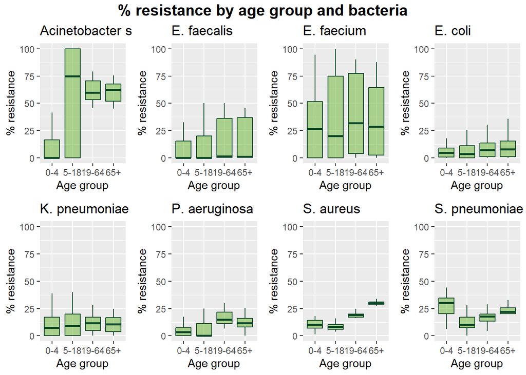

```
##
## Call:
## PCA(X = numeric_age, graph = FALSE)
##
##
## Eigenvalues
##                        Dim.1   Dim.2   Dim.3   Dim.4
## Variance               2.895   1.025   0.057   0.023
## % of var.             72.363  25.635   1.426   0.576
## Cumulative % of var.  72.363  97.998  99.424 100.000
##
## Individuals
##                        Dist    Dim.1    ctr   cos2    Dim.2    ctr   cos2
## Acinetobacter spp. |  4.215 |  4.115 73.116  0.953 | -0.909 10.062  0.046 |
## E. coli            |  1.313 | -1.181  6.024  0.809 | -0.563  3.860  0.184 |
## E. faecalis        |  1.966 | -1.676 12.129  0.726 | -1.010 12.445  0.264 |
## E. faecium         |  1.673 |  0.681  2.005  0.166 |  1.511 27.822  0.816 |
## K. pneumoniae      |  0.908 | -0.830  2.973  0.836 | -0.310  1.174  0.117 |
## P. aeruginosa      |  1.133 | -0.898  3.483  0.628 | -0.602  4.411  0.282 |
## S. aureus          |  0.589 |  0.036  0.006  0.004 |  0.068  0.056  0.013 |
## S. pneumoniae      |  1.841 | -0.247  0.264  0.018 |  1.815 40.170  0.972 |
##                     Dim.3    ctr   cos2
## Acinetobacter spp.  0.095  1.978  0.001 |
## E. coli             0.093  1.911  0.005 |
## E. faecalis         0.174  6.634  0.008 |
## E. faecium          0.089  1.721  0.003 |
## K. pneumoniae       0.195  8.369  0.046 |
## P. aeruginosa      -0.175  6.694  0.024 |
## S. aureus          -0.568 70.664  0.930 |
## S. pneumoniae       0.096  2.028  0.003 |
##
## Variables
##                       Dim.1    ctr   cos2    Dim.2    ctr   cos2    Dim.3
## G1_0_4             | -0.025  0.022  0.001 |  0.999 97.329  0.998 |  0.035
## G2_5_18            |  0.976 32.897  0.952 | -0.126  1.547  0.016 |  0.168
## G3_19_64           |  0.990 33.880  0.981 |  0.065  0.408  0.004 |  0.000
## G4_65plus          |  0.980 33.201  0.961 |  0.086  0.716  0.007 | -0.166
##                       ctr   cos2
## G1_0_4              2.202  0.001 |
## G2_5_18            49.476  0.028 |
## G3_19_64            0.000  0.000 |
## G4_65plus          48.322  0.028 |
```

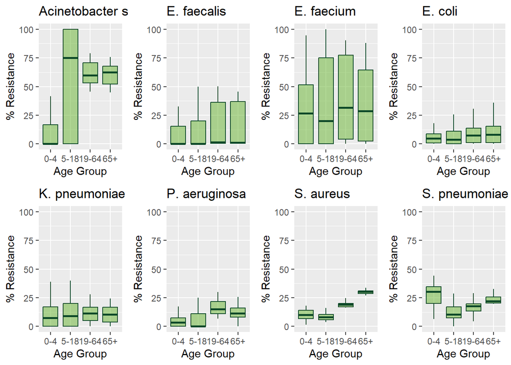

```r
bacteria_list <- as.list(unique(df_ES$Bacteria))

plots_age <- lapply(bacteria_list, function(bac) {
  ggplot(df_age_ES[df_age_ES$Bacteria == bac, ], aes(x = Category, y = Resistance)) +
    geom_boxplot(fill = "#65b32e", colour = "#0c4828", alpha = 0.5, outlier.shape = NA) +
    coord_cartesian(ylim = c(0, 100)) +
    ggtitle(bac) +
    labs(x = "Age Group", y = "% Resistance")
})

grid.arrange(grobs = plots_age, ncol = 4)
```

**Interpretation:**

## 1.2 1.2 ANOVA: Factors Influencing Resistance

The model includes:

- Age group
- Bacteria
- Antibiotic
- Year
- All interactions

```r
anova_age <- aov(Resistance ~ Category * Bacteria * Antibiotic * Year, data = df_age_ES)
summary(anova_age)
```

```
##                                     Df Sum Sq Mean Sq F value   Pr(>F)
## Category                             3  20020    6673  87.230  < 2e-16 ***
## Bacteria                             7 190318   27188 355.389  < 2e-16 ***
## Antibiotic                          11 124089   11281 147.457  < 2e-16 ***
## Year                                 1   6733    6733  88.011  < 2e-16 ***
## Category:Bacteria                   21  45612    2172  28.391  < 2e-16 ***
## Category:Antibiotic                 33   8304     252   3.289 1.51e-09 ***
## Bacteria:Antibiotic                 10 149966   14997 196.028  < 2e-16 ***
## Category:Year                        3    429     143   1.868    0.133
## Bacteria:Year                        7   6188     884  11.556 2.39e-14 ***
## Antibiotic:Year                     11   3155     287   3.749 2.63e-05 ***
## Category:Bacteria:Antibiotic        30   6963     232   3.034 9.00e-08 ***
## Category:Bacteria:Year              21   4512     215   2.809 2.40e-05 ***
## Category:Antibiotic:Year            33   1944      59   0.770    0.823
## Bacteria:Antibiotic:Year            10   2761     276   3.609 9.33e-05 ***
## Category:Bacteria:Antibiotic:Year   30   1604      53   0.699    0.888
## Residuals                         1431 109475      77
## ---
## Signif. codes:  0 '***' 0.001 '**' 0.01 '*' 0.05 '.' 0.1 ' ' 1
```

**Key findings:**

- All main factors and most interactions are statistically significant.
- Age, bacteria, antibiotic group, and year all influence resistance levels.

## 1.3 1.3 PCA: Age–Bacteria Resistance Patterns

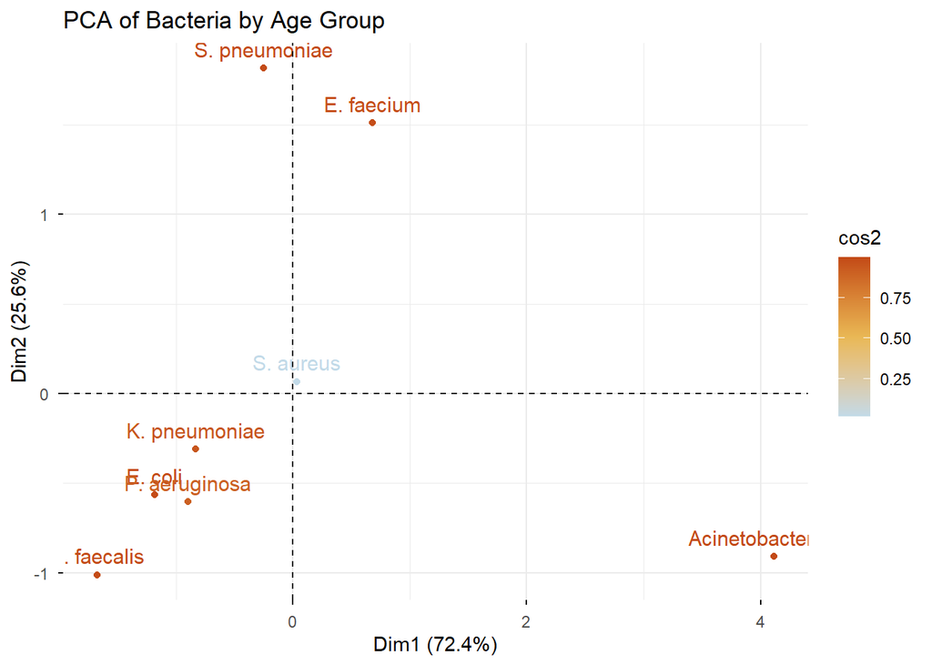

```r
# Create median resistance table
table_age <- dcast(df_age_ES, Bacteria ~ Category, value.var = "Resistance", fun.aggregate = median)

# Set row names
rownames(table_age) <- table_age$Bacteria

# Run PCA
pca <- PCA(table_age[, -1], graph = FALSE)

# PCA plots
fviz_pca_ind(pca, col.ind = "cos2",
             gradient.cols = c("#c2dae8", "#e9b855", "#c34a17"),
             title = "PCA of Bacteria by Age Group")
```

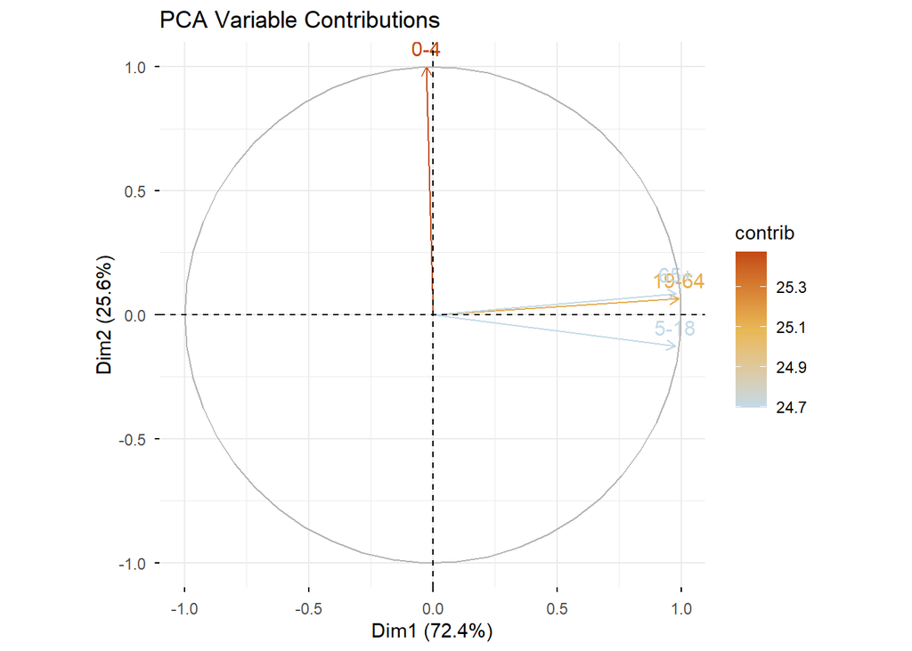

```r
fviz_pca_var(pca, col.var = "contrib",
             gradient.cols = c("#c2dae8", "#e9b855", "#c34a17"),
             axes.linetype = "dashed",
             title = "PCA Variable Contributions")
```

**Insights:**

- Two principal components explain **98%** of total variance.
- Age groups 5–18, 19–64, and 65+ cluster together.
- Age group 0–4 behaves differently, especially for *S. pneumoniae*.

# 2 1.4 Correlation Matrix of Age Groups

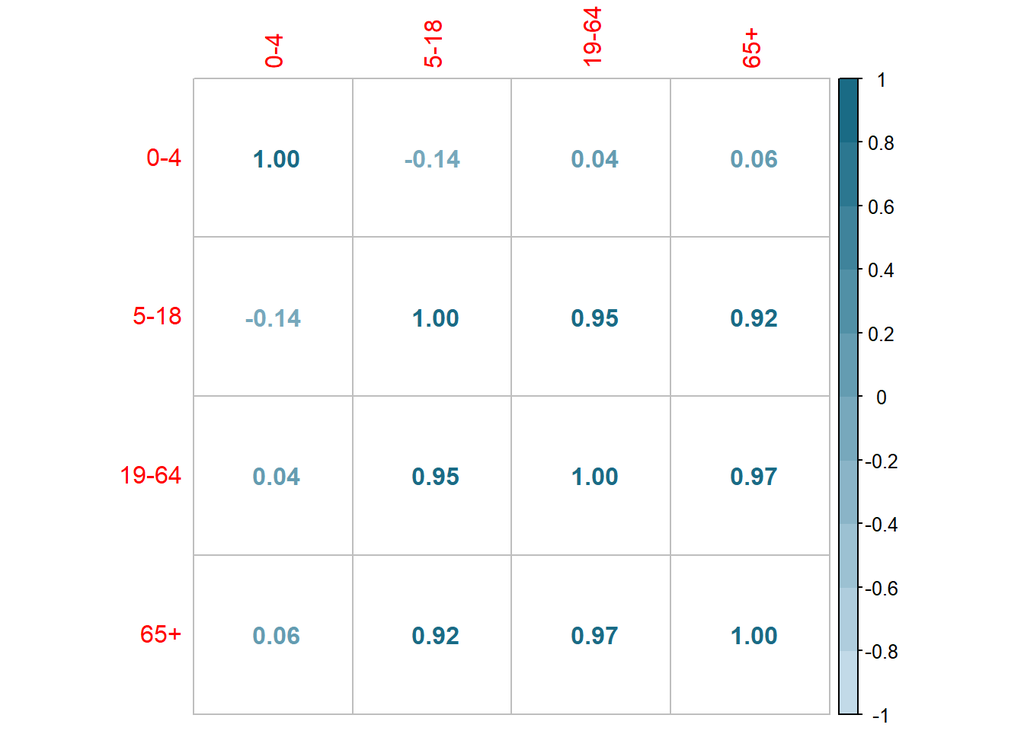

```r
library(corrplot)

# Extract numeric columns
age_numeric <- table_age[, -1]

# Compute correlation matrix
cor_matrix <- cor(age_numeric, use = "pairwise.complete.obs")

# Plot correlation matrix
corrplot(cor_matrix, method = "number", col = colorRampPalette(c("#c2dae8", "#1a6b85"))(10))
```

Strong positive correlations exist among all age groups except 0–4, which behaves independently.

# 3 2. Resistance by Gender

## 3.1 2.1 Boxplots of Resistance by Gender and Bacteria

```r
source("../scripts/05_analysis_gender.R")
```

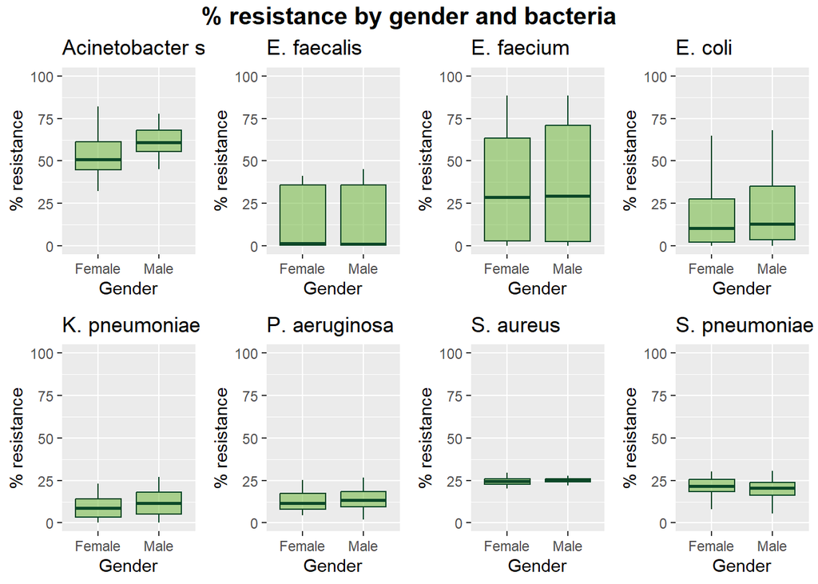

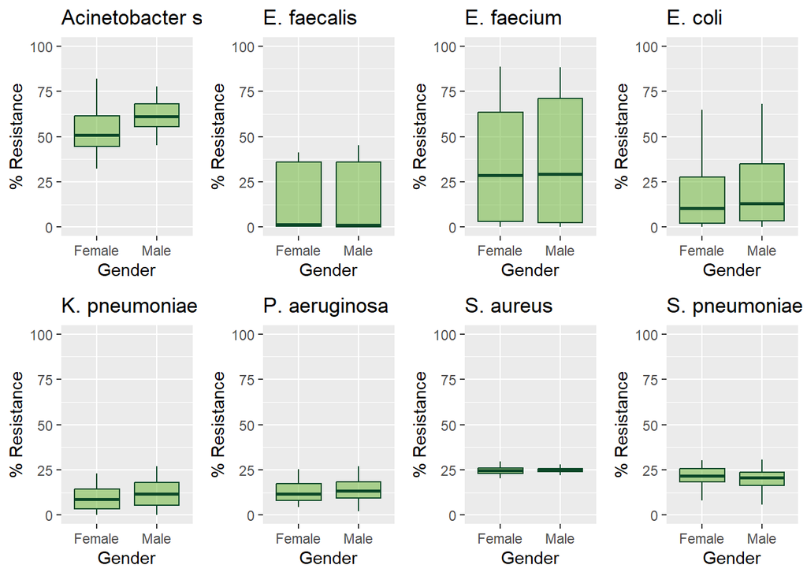

```r
plots_gender <- lapply(bacteria_list, function(bac) {
  ggplot(df_gender_ES[df_gender_ES$Bacteria == bac, ], aes(x = Category, y = Resistance)) +
    geom_boxplot(fill = "#65b32e", colour = "#0c4828", alpha = 0.5, outlier.shape = NA) +
    coord_cartesian(ylim = c(0, 100)) +
    ggtitle(bac) +
    labs(x = "Gender", y = "% Resistance")
})

grid.arrange(grobs = plots_gender, ncol = 4)
```

**Findings:**

- Resistance patterns are similar between males and females.
- *Acinetobacter spp.* again shows the highest resistance.
- *E. faecalis* shows high variability but low resistance.

# 4 2.2 ANOVA: Influence of Gender, Bacteria, Antibiotic and Year

```r
anova_gender <- aov(Resistance ~ Category * Bacteria * Antibiotic * Year, data = df_gender_ES)
summary(anova_gender)
```

```
##                                    Df Sum Sq Mean Sq  F value   Pr(>F)
## Category                            1    792     792   61.014 1.88e-14 ***
## Bacteria                            7 118508   16930 1304.141  < 2e-16 ***
## Antibiotic                         12 160625   13385 1031.115  < 2e-16 ***
## Year                                1   4243    4243  326.816  < 2e-16 ***
## Category:Bacteria                   7    670      96    7.372 1.38e-08 ***
## Category:Antibiotic                12    262      22    1.680 0.066597 .
## Bacteria:Antibiotic                10  85526    8553  658.826  < 2e-16 ***
## Category:Year                       1      1       1    0.097 0.756065
## Bacteria:Year                       7   4755     679   52.326  < 2e-16 ***
## Antibiotic:Year                    12   1905     159   12.231  < 2e-16 ***
## Category:Bacteria:Antibiotic       10    298      30    2.299 0.011645 *
## Category:Bacteria:Year              7    374      53    4.120 0.000186 ***
## Category:Antibiotic:Year           12     42       3    0.268 0.993656
## Bacteria:Antibiotic:Year           10   1202     120    9.261 1.43e-14 ***
## Category:Bacteria:Antibiotic:Year  10     70       7    0.541 0.861763
## Residuals                         762   9892      13
## ---
## Signif. codes:  0 '***' 0.001 '**' 0.01 '*' 0.05 '.' 0.1 ' ' 1
```

**Key results**:

- Significant differences exist between bacteria and gender.
- Some bacteria show slightly higher resistance in males.

# 5 2.3 Median Resistance Table by Gender and Bacteria

```r
table_gender <- dcast(df_gender_ES, Bacteria ~ Category, value.var = "Resistance", fun.aggregate = median)

# Round values
table_gender[,2:3] <- round(table_gender[,2:3], 2)

table_gender
```

```
##             Bacteria Female  Male
## 1 Acinetobacter spp.  50.76 61.09
## 2            E. coli  10.39 12.97
## 3        E. faecalis   1.46  1.08
## 4         E. faecium  28.76 29.33
## 5      K. pneumoniae   8.78 11.77
## 6      P. aeruginosa  11.75 13.25
## 7          S. aureus  24.62 25.10
## 8      S. pneumoniae  21.70 20.63
```

# 6 2.4 Correlation Between Male and Female Resistance

```r
cor(table_gender[, c("Male", "Female")], method = "pearson")
```

```
##             Male    Female
## Male   1.0000000 0.9892725
## Female 0.9892725 1.0000000
```

# 7 2.5 Difference in Resistance (Male – Female)

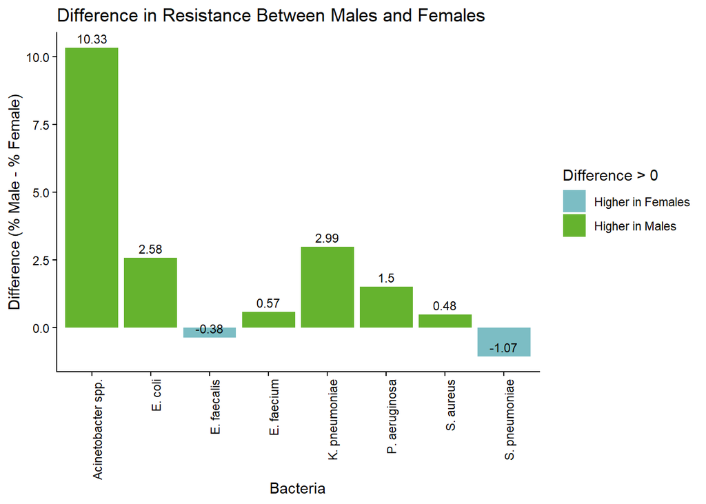

```r
table_gender$Difference <- table_gender$Male - table_gender$Female

ggplot(table_gender, aes(x = Bacteria, y = Difference, fill = Difference > 0)) +
  geom_bar(stat = "identity") +
  scale_fill_manual(values = c("#7cbdc4", "#65b32e"),
                    labels = c("Higher in Females", "Higher in Males")) +
  labs(y = "Difference (% Male - % Female)", x = "Bacteria",
       title = "Difference in Resistance Between Males and Females") +
  geom_text(aes(label = round(Difference, 2)), vjust = -0.5, size = 3) +
  theme_classic() +
  theme(axis.text.x = element_text(angle = 90, hjust = 1))
```

Most bacteria show slightly higher resistance in males, except:

- *E. faecalis*
- *S. pneumoniae*

These show slightly higher resistance in females.

# 8 3. Bacteria–Antibiotic Resistance Profiles

## 8.1 3.1 Median Resistance Table by Bacteria and Antibiotic

```r
source("../scripts/06_analysis_antibiotics.R")
```

```r
table_ab <- dcast(df_ES, Bacteria ~ Antibiotic, value.var = "Resistance", fun.aggregate = median)

# Convert to numeric and round
table_ab[, 2:ncol(table_ab)] <- apply(table_ab[, 2:ncol(table_ab)], 2, as.numeric)
table_ab[, 2:ncol(table_ab)] <- round(table_ab[, 2:ncol(table_ab)], 2)

table_ab
```

```
##             Bacteria    AG   AMP   C3G C3G/FQ/AG  CAR  CAZ    FQ   HGA   MAC
## 1 Acinetobacter spp. 51.15    NA    NA        NA 59.1   NA 66.57    NA    NA
## 2            E. coli 11.66 62.69  8.21      2.64  0.0   NA 25.59    NA    NA
## 3        E. faecalis    NA  1.11    NA        NA   NA   NA    NA 37.50    NA
## 4         E. faecium    NA 80.00    NA        NA   NA   NA    NA 26.81    NA
## 5      K. pneumoniae 13.46    NA 16.02      6.74  0.0   NA 16.67    NA    NA
## 6      P. aeruginosa 13.07    NA    NA        NA 16.4 8.28 20.61    NA    NA
## 7          S. aureus    NA    NA    NA        NA   NA   NA    NA    NA    NA
## 8      S. pneumoniae    NA    NA    NA        NA   NA   NA    NA    NA 21.36
##    MRSA   PEN PIP/TAZ TRIPLE  VAN   XDR
## 1    NA    NA      NA     NA   NA 46.27
## 2    NA    NA      NA     NA   NA    NA
## 3    NA    NA      NA     NA 0.00    NA
## 4    NA    NA      NA     NA 1.21    NA
## 5    NA    NA      NA     NA   NA    NA
## 6    NA    NA    7.69     10   NA    NA
## 7 22.15    NA      NA     NA   NA    NA
## 8    NA 17.18      NA     NA   NA    NA
```

# 9 3.2 Long Format for Visualization

```r
library(tidyr)

df_long <- gather(table_ab, key = "Antibiotic", value = "Resistance", -Bacteria)
df_long$Resistance <- as.numeric(df_long$Resistance)
```

# 10 3.3 Stacked Barplot of Antibiotics with Resistance > 10%

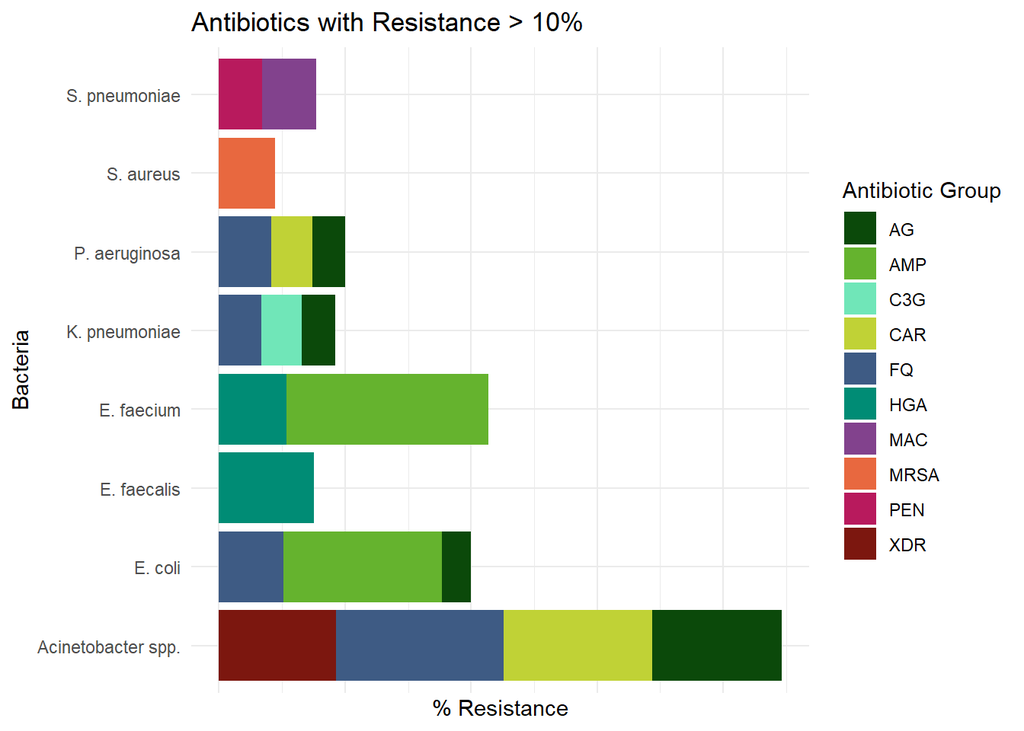

```r
library(dplyr)

df_filtered <- df_long %>%
  filter(!is.na(Resistance) & Resistance > 10)

palette_colors <- c("#0B490A", "#65b32e", "#70E6B8", "#C0D236",
                    "#3E5B84", "#008C75", "#82428D", "#E8683F",
                    "#B81A5D", "#7C170F")

ggplot(df_filtered, aes(x = Resistance, y = Bacteria, fill = Antibiotic)) +
  geom_col() +
  scale_fill_manual(values = palette_colors) +
  labs(x = "% Resistance", y = "Bacteria", fill = "Antibiotic Group",
       title = "Antibiotics with Resistance > 10%") +
  theme_minimal() +
  theme(axis.text.x = element_blank(),
        axis.ticks.x = element_blank())
```

## 10.1 4. Temporal Evolution of Resistance

# 11 4.1 Mean Resistance per Antibiotic and Year

```r
source("../scripts/07_time_series.R")
```

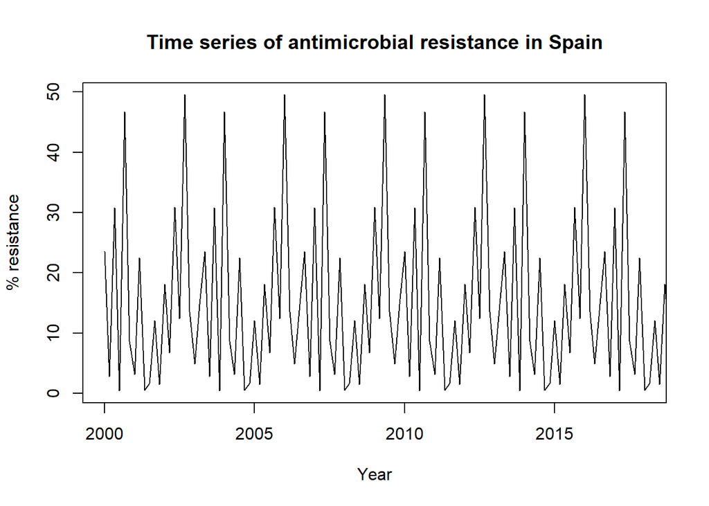

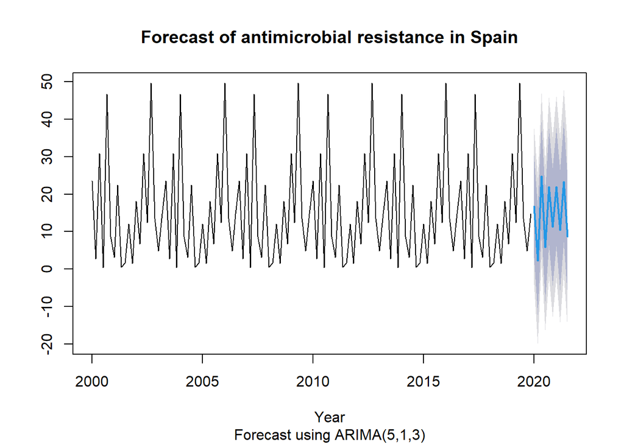

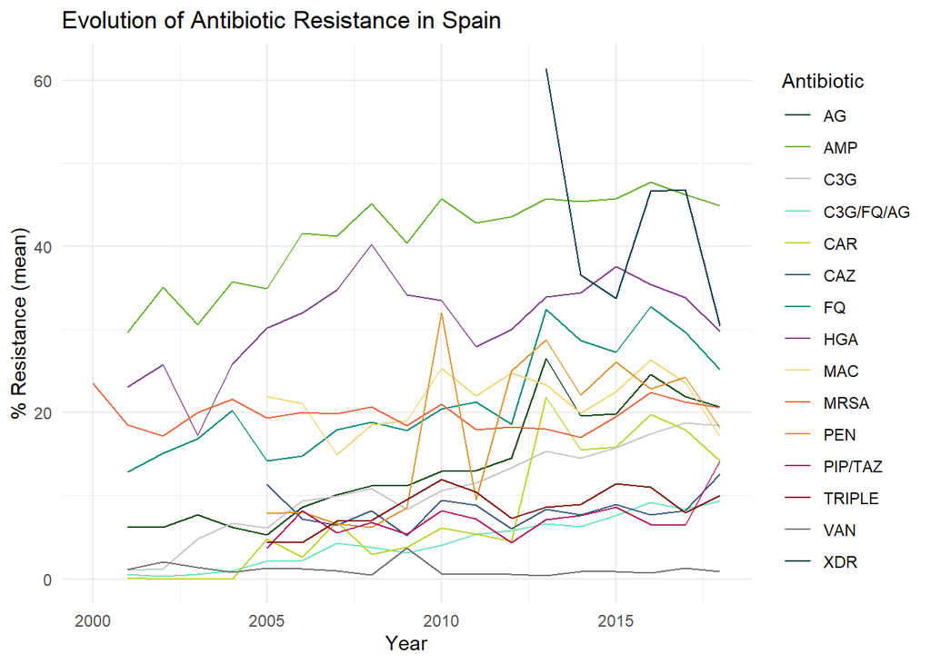

```r
mean_res <- df_ES %>%
  group_by(Antibiotic, Year) %>%
  summarise(mean_res = mean(Resistance), .groups = "drop")

palette2 <- c("#0B490A", "#65b32e", "#C7C7C7", "#70E6B8", "#C0D236",
              "#3E5B84", "#008C75", "#82428D", "#F1D676", "#E8683F",
              "#DC9635", "#B81A5D", "#7C170F", "#717171", "#003C50")

ggplot(mean_res, aes(x = Year, y = mean_res, color = Antibiotic)) +
  geom_line() +
  scale_color_manual(values = palette2) +
  labs(title = "Evolution of Antibiotic Resistance in Spain",
       x = "Year", y = "% Resistance (mean)") +
  theme_minimal()
```

# 12 4.2 Grouping Antibiotics: Betalactam vs Non‑Betalactam

```r
df_ES <- df_ES %>%
  mutate(Group = case_when(
    Antibiotic %in% c("AMP", "CAZ", "PIP/TAZ", "C3G", "CAR", "HGA", "PEN") ~ "Betalactam",
    Antibiotic %in% c("TRIPLE", "XDR", "AG", "FQ", "C3G/FQ/AG", "MAC", "VAN", "MRSA") ~ "Non-Betalactam"
  ))
```

# 13 4.3 Betalactam Resistance Over Time

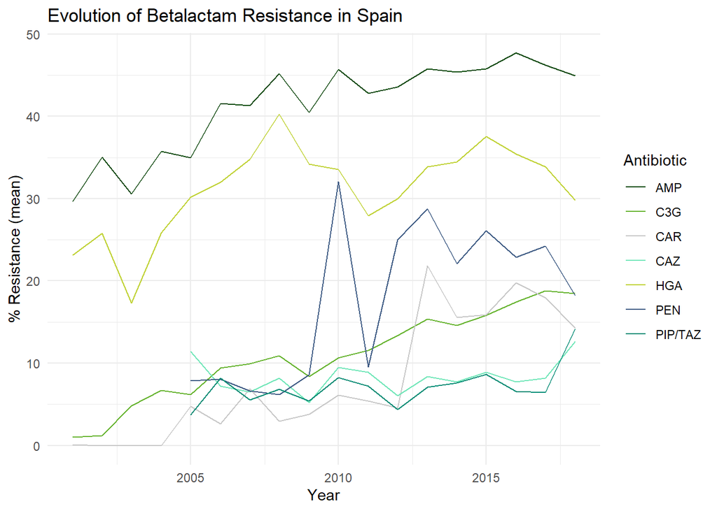

```r
df_betalactam <- subset(df_ES, Group == "Betalactam")

mean_betalactam <- df_betalactam %>%
  group_by(Antibiotic, Year) %>%
  summarise(mean_res = mean(Resistance), .groups = "drop")

ggplot(mean_betalactam, aes(x = Year, y = mean_res, color = Antibiotic)) +
  geom_line() +
  scale_color_manual(values = palette2) +
  labs(title = "Evolution of Betalactam Resistance in Spain",
       x = "Year", y = "% Resistance (mean)") +
  theme_minimal()
```

All beta‑lactam‑related groups show an **upward trend**, indicating increasing resistance over time.

# 14 4.4 Non‑Betalactam Resistance Over Time

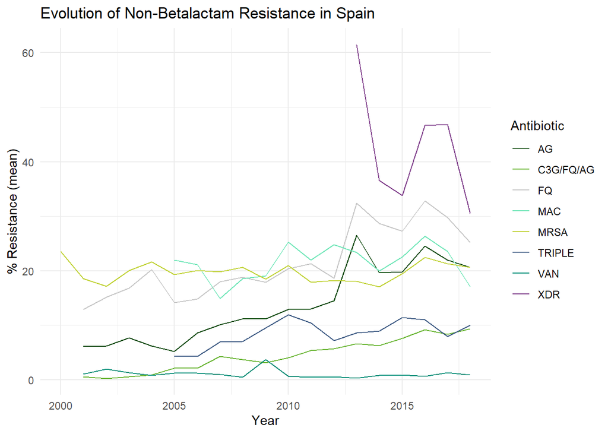

```r
df_nonbetalactam <- subset(df_ES, Group == "Non-Betalactam")

mean_nonbetalactam <- df_nonbetalactam %>%
  group_by(Antibiotic, Year) %>%
  summarise(mean_res = mean(Resistance), .groups = "drop")

ggplot(mean_nonbetalactam, aes(x = Year, y = mean_res, color = Antibiotic)) +
  geom_line() +
  scale_color_manual(values = palette2) +
  labs(title = "Evolution of Non-Betalactam Resistance in Spain",
       x = "Year", y = "% Resistance (mean)") +
  theme_minimal()
```

Mixed patterns:

- Increasing: aminoglycosides, fluoroquinolones
- Stable or decreasing: macrolides, vancomycin

# 15 5. Predictive Modeling

## 15.1 5.1 Time Series Forecasting (ARIMA)

```r
# Executed inside 07_time_series.R
```

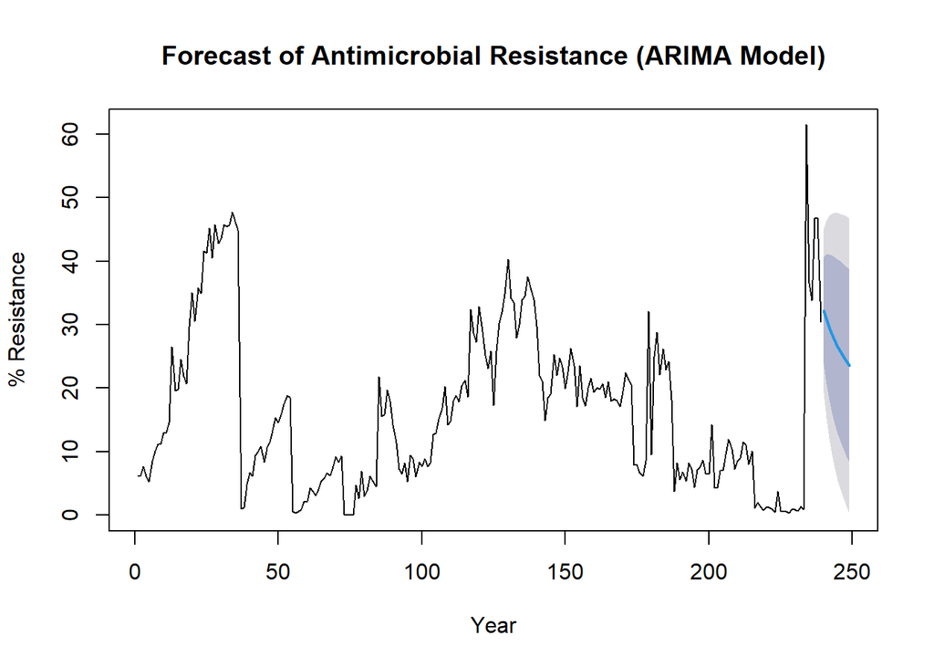

```r
# Prepare time series using the mean resistance across all antibiotics
ts_data <- ts(mean_res$mean_res, frequency = 1)

# Fit ARIMA model
fit <- auto.arima(ts_data)

# Forecast and plot
forecast_values <- forecast(fit)
plot(forecast_values,
     main = "Forecast of Antimicrobial Resistance (ARIMA Model)",
     ylab = "% Resistance",
     xlab = "Year")
```

# 16 5.2 Classification Tree for Predicting Resistance

```r
source("../scripts/08_classification_tree.R")
```

[figure not shown]

[figure not shown]

```r
# Build classification tree
tree_model <- rpart(Resistance ~ Bacteria + Antibiotic + Year,
                    data = df_ES,
                    method = "anova")

# Plot tree
fancyRpartPlot(tree_model)
```

**Insights:**

- Bacteria type is the strongest predictor of resistance.
- Antibiotic group is the second most important factor.
- The model can support empirical antibiotic selection.

# 17 Reproducibility information

sessionInfo()

```r
pkgs <- sessionInfo()$otherPkgs
sink("requirements.txt")
for (p in names(pkgs)) {
  cat(paste0(p, "==", pkgs[[p]]$Version, "\n"))
}
sink()
```

# 18 References

- European Centre for Disease Prevention and Control. (2021). *Surveillance of antimicrobial resistance in Europe 2021*. ECDC. https://www.ecdc.europa.eu
- Fenske, S. (2021). *European Antimicrobial Resistance Dataset (EARS-Net)* [Data set]. Kaggle. https://www.kaggle.com/datasets/samfenske/euro-resistance
- World Health Organization. (2014). *Antimicrobial resistance: Global report on surveillance*. WHO Press. https://www.who.int/publications/i/item/9789241564748
- Cassini, A., Högberg, L. D., Plachouras, D., Quattrocchi, A., Hoxha, A., Simonsen, G. S., … & Suetens, C. (2019). Attributable deaths and disability-adjusted life-years caused by infections with antibiotic-resistant bacteria in the EU and the European Economic Area in 2015: A population-level modelling analysis. *The Lancet Infectious Diseases, 19*(1), 56–66. https://doi.org/10.1016/S1473-3099(18)30605-4
- O’Neill, J. (2016). *Tackling drug-resistant infections globally: Final report and recommendations*. Review on Antimicrobial Resistance. https://amr-review.org